# Projet: Reconnaissance faciale

Sébastien Vingadessin (36008909) et Ben yamine Mze Hamadi

21/10/2021

## Question 1. Lecture des données

### Liste des fichiers d’images de référence

```r
ref<-list.files(path = "./referenceFaceData",full.names=TRUE)
```

### Chargement de la librairie pixmap

```r
library(pixmap)
```

### Liste des matrices des images de référence

```r
imgRefMat=lapply(imgRef,function(x){x@grey[0:100,0:90]})
```

### Conversion des matrices d’images de référence en vecteurs

```r
imgRefVector=lapply(imgRefMat,function(x){as.vector(t(x))})
#length(imgRefVector[[1]])
```

### Construction de la matrice dont les lignes sont les vecteurs de imgRefVector

```r
imgRefMatPCA=t(sapply(imgRefVector,rbind))
```

### Noms des lignes de la matrice imgRefMatPCA

```r
rownames(imgRefMatPCA)=lapply(1:nrow(imgRefMatPCA),function(x){v=paste("r",x)})
imgRefMatPCA[,1:5]
```

```
##           [,1]      [,2]      [,3]      [,4]      [,5]
## r 1  0.4666667 0.4745098 0.4784314 0.4705882 0.4745098
## r 2  0.4627451 0.4470588 0.4588235 0.4509804 0.4588235
## r 3  0.4470588 0.4509804 0.4509804 0.4431373 0.4392157
## r 4  0.4588235 0.4392157 0.4509804 0.4549020 0.4470588
## r 5  0.1960784 0.2235294 0.2196078 0.2313725 0.2274510
## r 6  0.2627451 0.2431373 0.3450980 0.3098039 0.3294118
## r 7  0.3607843 0.3647059 0.3764706 0.3529412 0.3607843
## r 8  0.1921569 0.2549020 0.2078431 0.2196078 0.2000000
## r 9  0.2156863 0.2196078 0.2196078 0.2039216 0.2274510
## r 10 0.1803922 0.1647059 0.1803922 0.1490196 0.1882353
```

### Liste des fichiers d’images test

```r
test<-list.files(path = "./testFaceData",full.names=TRUE)
test
```

```
## [1] "./testFaceData/0409.pgm" "./testFaceData/0803.pgm"
## [3] "./testFaceData/107.pgm"  "./testFaceData/2204.pgm"
## [5] "./testFaceData/3201.pgm"
```

### Lecture des fichier d’images test

```r
imgTest=lapply(test,read.pnm)
```

```r
#lapply(imgTest,plot)
```

### Liste des matrices des images test

```r
imgTestMat=lapply(imgTest,function(x){x@grey[0:100,0:90]})
```

### Conversion des matrices d’images test en vecteurs

```r
imgTestVector=lapply(imgTestMat,function(x){as.vector(t(x))})
```

### Construction de la matrice dont les lignes sont les vecteurs de imgTestVector

```r
imgTestMatPCA=t(sapply(imgTestVector,rbind))
```

### Noms des lignes de la matrice imgTestMatPCA

```r
rownames(imgTestMatPCA)=lapply(1:nrow(imgTestMatPCA),function(x){v=paste("t",x)})
```

### Construction de la matrice de données contenant les vecteurs visages de référence et vecteurs visages test

```r
donnees<- rbind(imgRefMatPCA, imgTestMatPCA)
dim(donnees)
```

```
## [1]   15 9000
```

## Question 2. ACP

### Chargement de la librairie FactoMineR

```r
library(FactoMineR)
```

### Construction de l’ACP par la matrice des données des vecteurs des visages de référence et des visages tests

```r
acp<-PCA(donnees, scale.unit = FALSE, ncp = Inf)
```

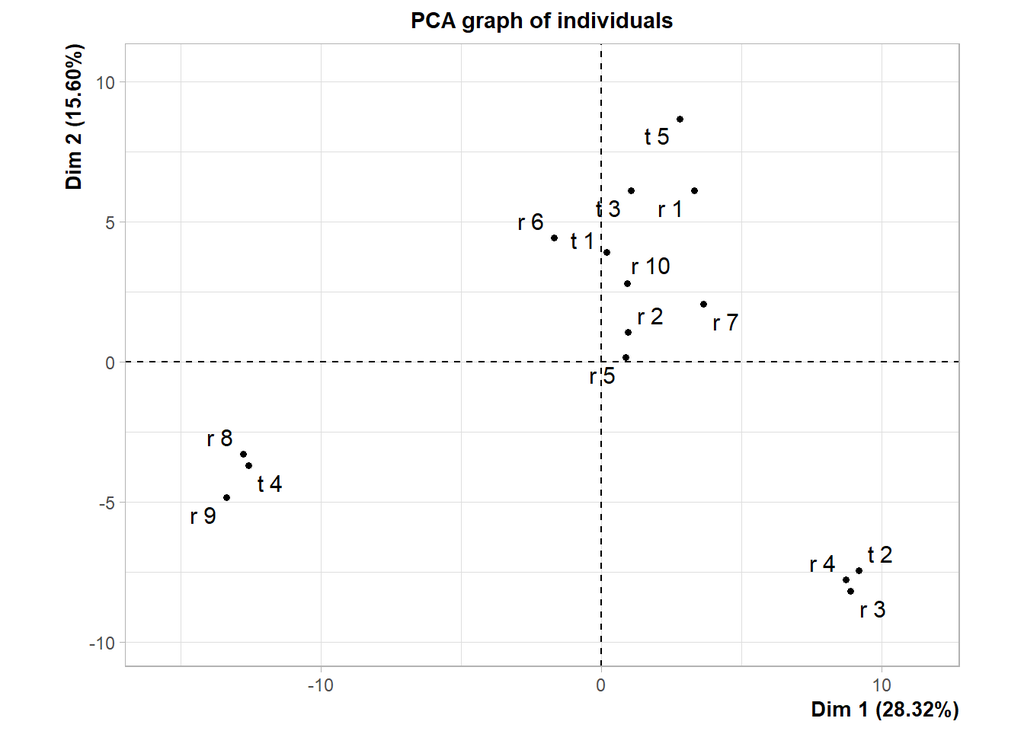

[figure not shown]

## Question 2.a (Ben yamine Mze Hamadi)

### Fonction calculant le nombre k d’axes factoriels, suggéré par le critère de Kaiser

```r
#Valeurs propres données par l'ACP
Vp<-acp$eig[,1]
```

kaiser est une fonction qui calcule le nombre d’axes factoriels suggéré par le critère de Kaiser. Elle prend en paramètre les valeurs propres des données reçues par l’ACP et renvoie un entier.

```r
kaiser<-function(valP){
  Imoy<-sum(valP)/length(valP)
  res<-length(valP[valP>Imoy])
  return(res)
}

k<-kaiser(Vp)
k
```

```
## [1] 4
```

## Question 2.b (Sébastien Vingadessin)

### Fonction déterminant le pourcentage d’inertie expliquée par le sous-espace factoriel Ek retenu

La fonction pInexp détermine le pourcentage d’inertie expliqué. Elle prend en paramètre les valeurs propres des données reçues par l’ACP. Et renvoie le pourcentage d’inertie expliqué sous l’espace factoriel retenu par l’application de la fonction Kaiser vue précédemment.

```r
pInexp<-function(valP){
  In<-sum(valP)
  return(sum(valP[1:k])*100/In)
}

pInexp(Vp)
```

```
## [1] 67.20879
```

## Question 2.c (Ben yamine Mze Hamadi)

### Fonction qui, pour chaque visage test, détermine le plan factoriel P sur lequel le visage test est mieux représenté, ainsi que le pourcentage d’inertie expliquée par P

La fonction planFact détermine le plan factoriel sur lequel le visage test est le mieux représenté, ainsi que le pourcentage d’inertie. Elle prend en paramètre les valeurs des cosinus données par l’ACP. Elle renvoie une matrice présentant les dimensions des plans factoriels retenus ainsi que les pourcentages d’inertie expliquée par le plan en question.

```r
planFact<-function(tab){
  res<-c()
  ij<-c(0,0)

  for(n in 1:5){
    max<-0
    for(i in 1:k){
      for(j in 1:k){
        if(j>i){
          if(tab[10+n,i]+tab[10+n,j] > max){
            max = tab[10+n,i]+tab[10+n,j]
            ij=c(i,j)
          }
        }
      }
    }
    res = c(res,ij,(Vp[ij[1]]+Vp[ij[2]])*100/sum(Vp))
  }

  M<-matrix(res,ncol = 5)
  rownames(M)=c("dim1","dim2","%inertie")
  colnames(M)=c("image 1","image 2","image 3","image 4","image 5")
  return(M)
}
```

### Application de la fontion PlanF définie précédemment

```r
cos<-acp$ind$cos2
planF<-planFact(cos)
planF
```

```
##           image 1  image 2  image 3  image 4  image 5
## dim1      2.00000  1.00000  2.00000  1.00000  2.00000
## dim2      3.00000  2.00000  3.00000  2.00000  3.00000
## %inertie 30.13729 43.91256 30.13729 43.91256 30.13729
```

## Question 2.d (Sébastien Vingadessin)

### Fonction qui, pour chaque visage test, représente graphiquement l’ensemble des visages de référence et le visage test en question sur le plan P

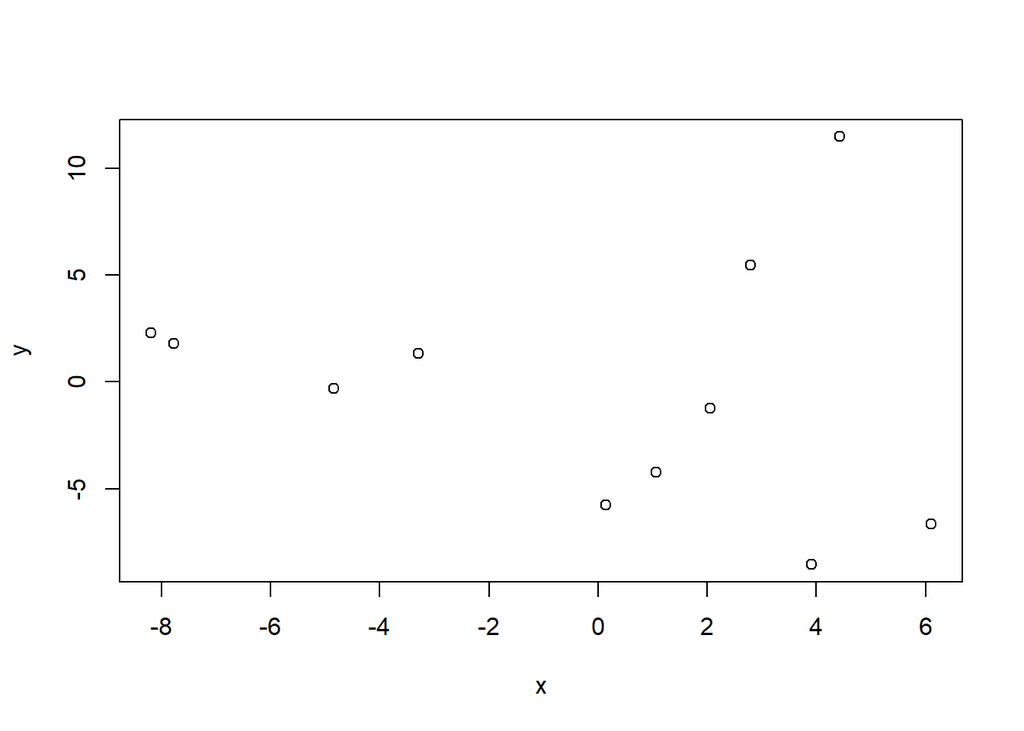

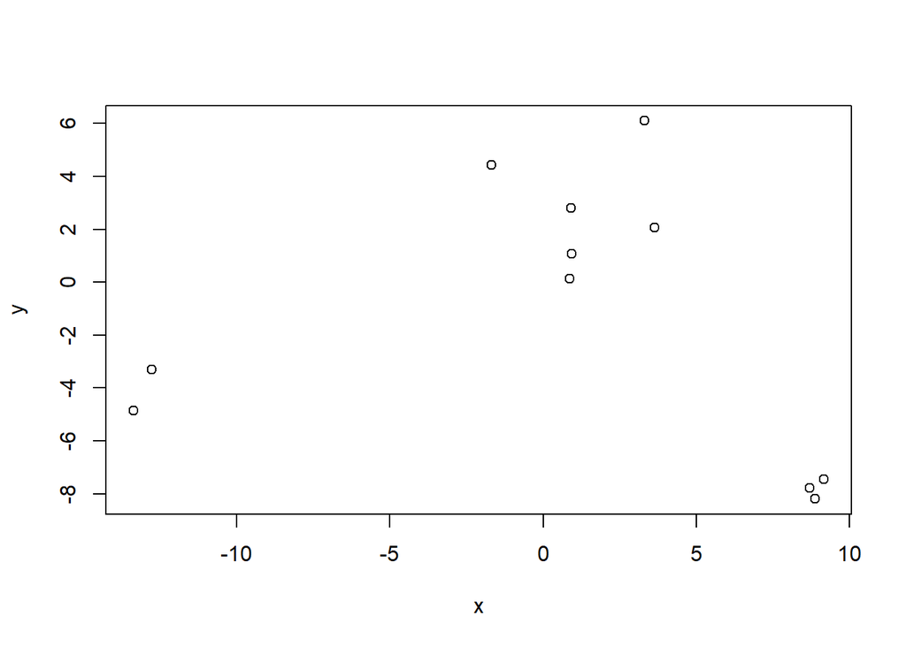

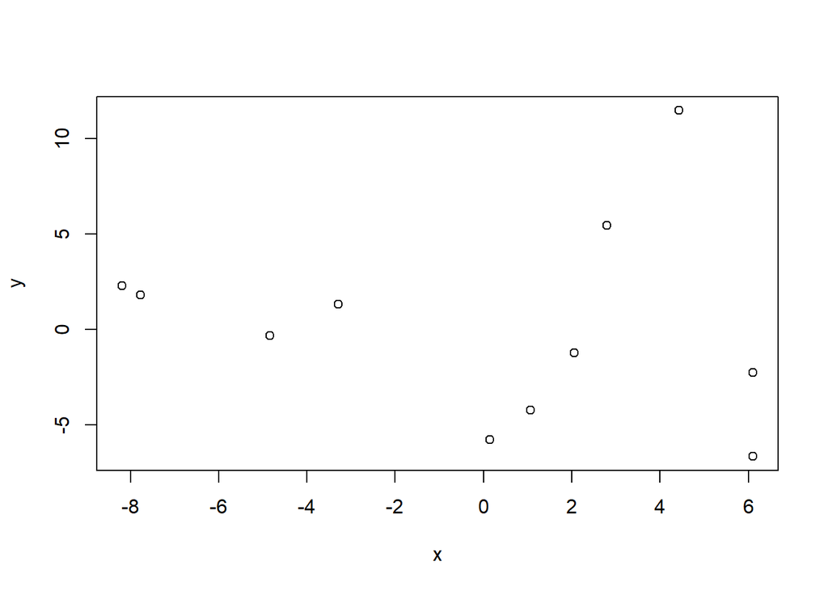

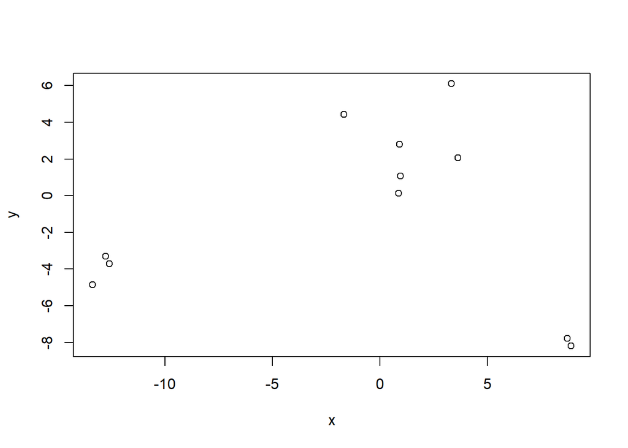

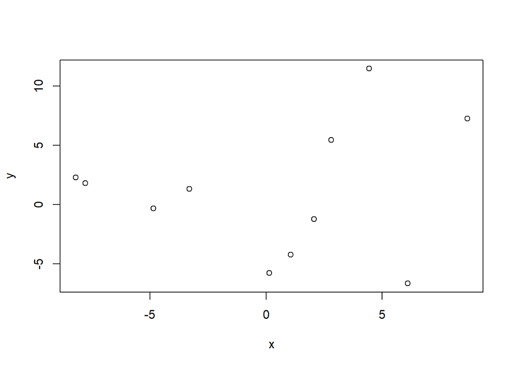

```r
coor<-acp$ind$coord

for(p in 1:5){
  x<-coor[,planF[1,p]]
  x=c(x[1:10],coor[10+p,planF[1,p]])
  y<-coor[,planF[2,p]]
  y=c(y[1:10],coor[10+p,planF[2,p]])

  plot(x,y,type = "p")
}
```

## Question 2.e (Sébastien Vingadessin)

### Fonction qui, pour chaque visage test, détermine le(s) visage(s) le(s) mieux représenté(s) parmi les plus proches du visage test au sens de la distance euclidienne

```r
distTest<-function(cord){
  res<-matrix(c(1:5,rep(0,5)),ncol = 2)
  colnames(res) = c("test","ref")

  #image test t

  for(t in 1:5){
    num<-0
    dmin<-1000000
    m<-matrix(c(1:(2*k)),nrow=2)
    m[1,]=cord[10+t,1:k]

    for(i in 1:10){
      m[2,]=cord[i,1:k]
      if(dist(m,method = "euclidean") < dmin) {
        dmin = dist(m,method = "euclidean")
        num = i
      }
    }

    res[t,2] = num
  }

  return(res)
}

distTest(coor)
```

```
##      test ref
## [1,]    1   1
## [2,]    2   4
## [3,]    3   2
## [4,]    4   9
## [5,]    5  10
```

## Question 2.f (Ben yamine Mze Hamadi)

### Fonction qui, pour chaque visage test, affiche simultanément le visage test et le(s) visage(s) identifié(s)

```r
identif<-function(cord){
  tab<-distTest(cord)

  for(i in 1:5){
    lapply(imgTest[i],plot)
    lapply(imgRef[tab[i,2]],plot)
  }
}
```

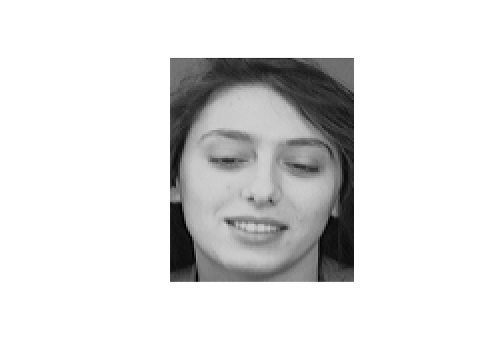

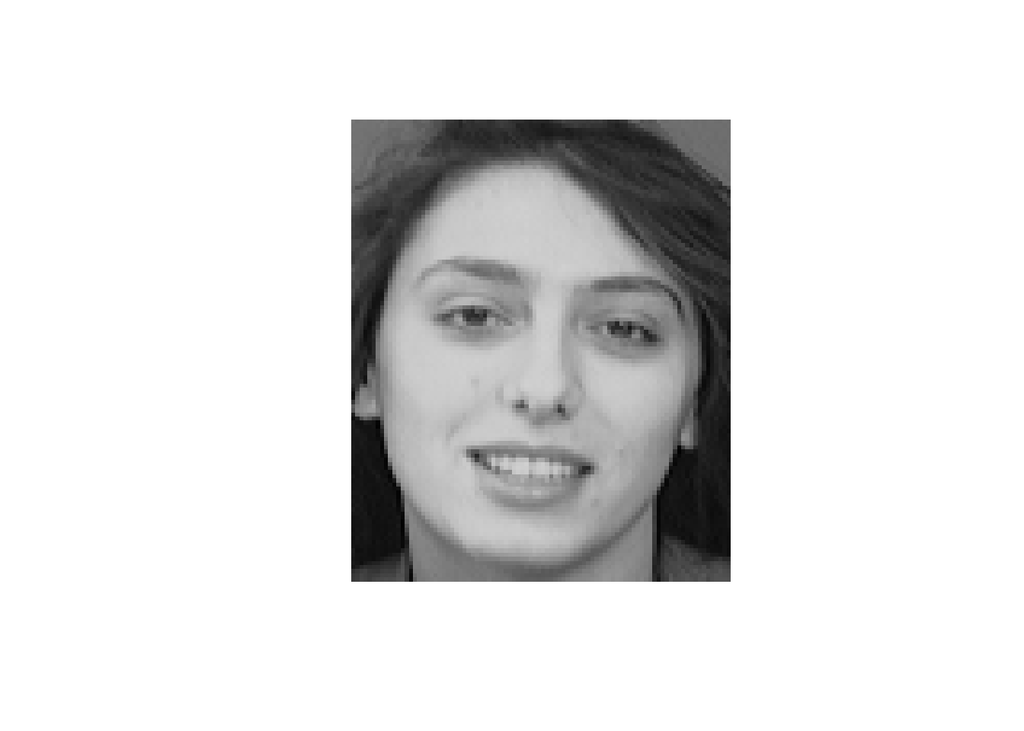

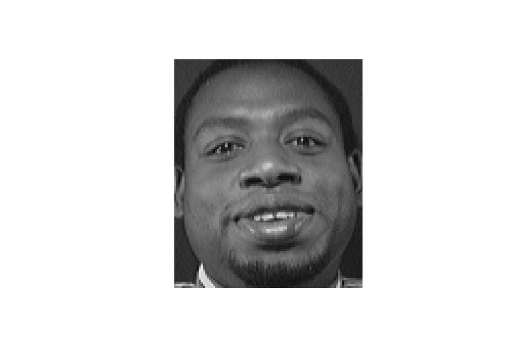

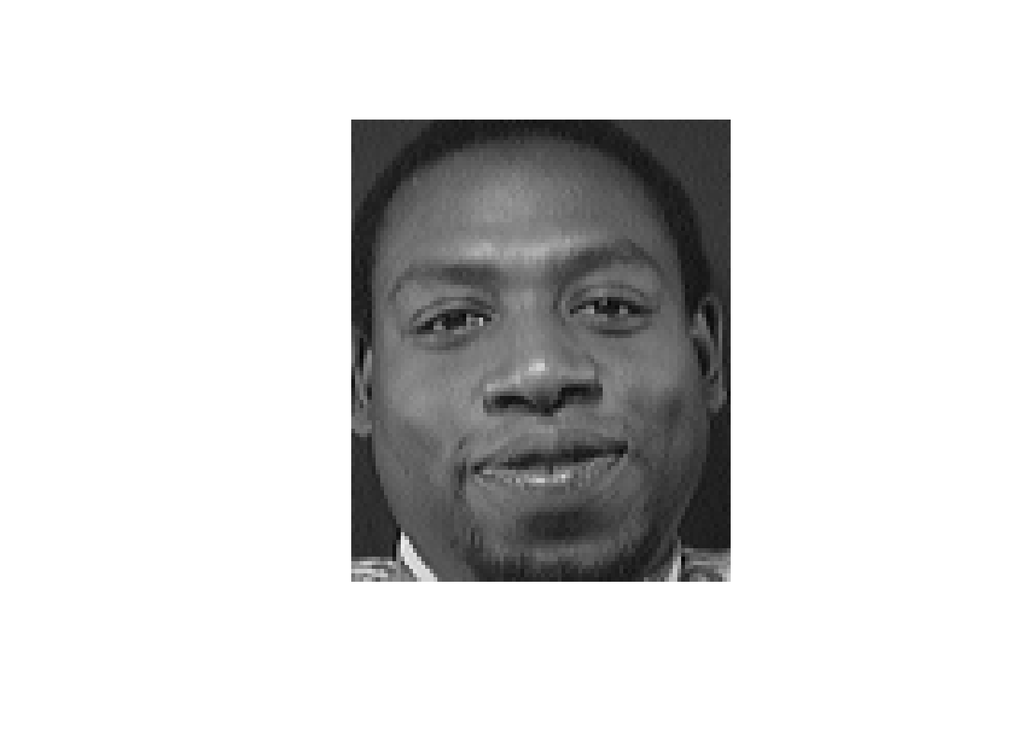

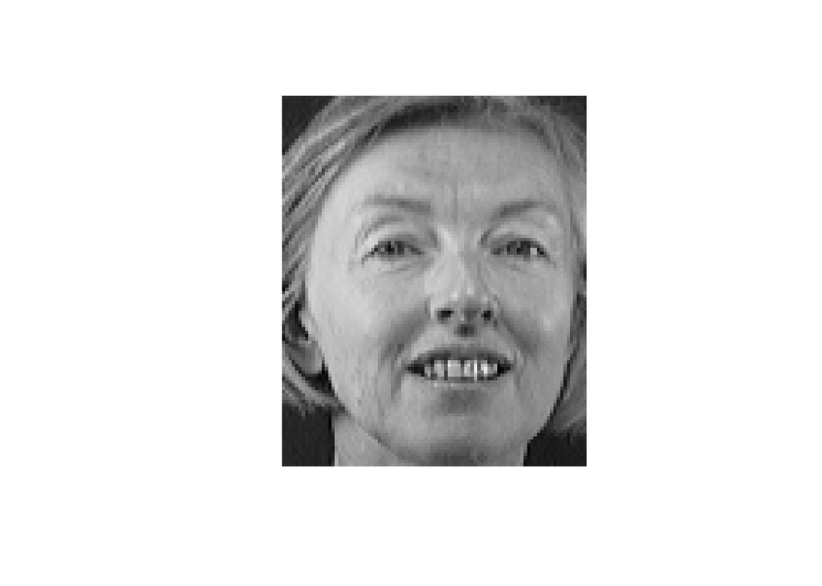

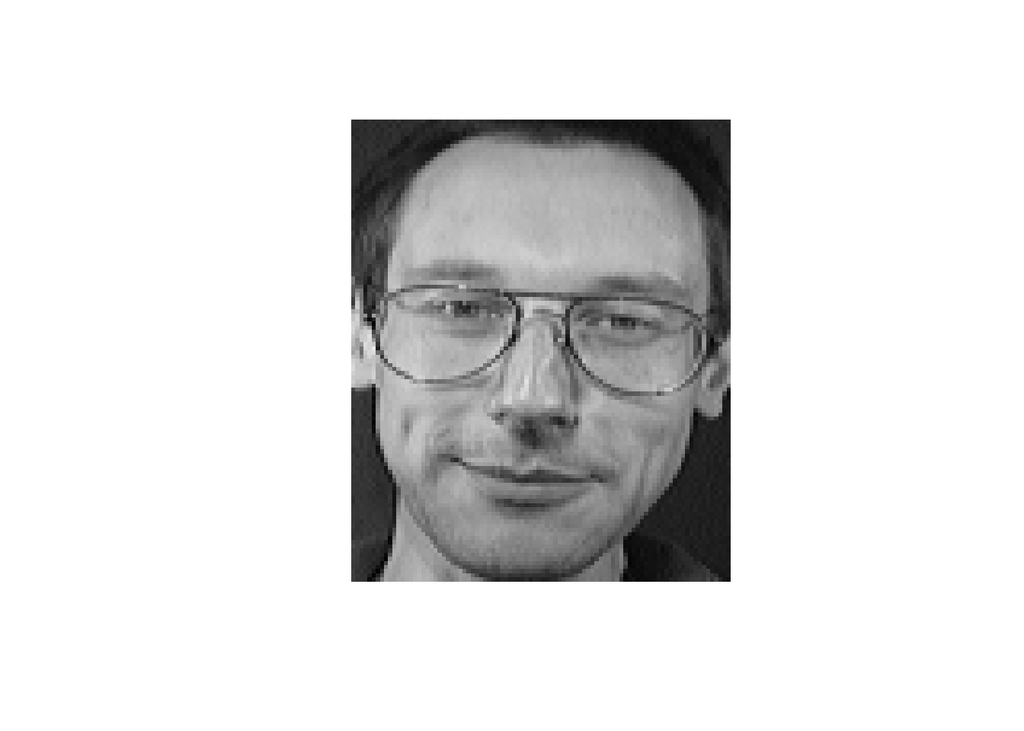

```r
identif(coor)
```

## Question 3. (Ben yamine Mze Hamadi)

### Classification ascendante hiérarchique (CAH) du projeté du nuage de visages sur le sous-espace principal Ek

```r
#Nuage de point projeté
nuage<-coor[,1:4]

#Matrice des dissimilarités du nuage, selon la distance euclidienne
d<-dist(nuage, method = "euclidean")
d
```

```
##            r 1       r 2       r 3       r 4       r 5       r 6       r 7
## r 2   6.263142
## r 3  18.031784 13.924646
## r 4  17.215883 13.226032  1.445742
## r 5   6.929748  1.975256 14.112155 13.474869
## r 6  20.060906 18.300065 21.324934 20.652178 20.168428
## r 7   6.760119  4.493674 12.496533 11.656833  6.196717 15.479998
## r 8  20.456108 15.479127 22.229761 21.976459 15.758801 19.431640 17.700617
## r 9  21.050096 15.988617 22.686037 22.390438 16.044521 21.040905 18.534074
## r 10 18.798556 15.713957 17.550090 18.129963 16.201840 21.729415 15.756983
## t 1   4.385111  5.262898 18.564082 17.810313  4.950416 21.577602  8.380770
## t 2  16.241971 12.606188  3.218966  2.029094 12.746480 21.215800 11.138009
## t 3   6.623127  6.132605 16.971572 16.561247  7.197670 18.059906  6.734343
## t 4  19.750387 14.793726 22.164205 21.857970 14.860381 20.566126 17.442651
## t 5  14.736266 14.138616 18.619466 18.444847 15.768015 13.266103 11.621747
##            r 8       r 9      r 10       t 1       t 2       t 3       t 4
## r 2
## r 3
## r 4
## r 5
## r 6
## r 7
## r 8
## r 9   2.422683
## r 10 19.057799 20.770075
## t 1  17.909693 18.157237 19.033759
## t 2  22.444781 22.734925 19.157981 16.853073
## t 3  17.192439 18.367139 12.579667  7.552794 16.334906
## t 4   2.162372  1.510550 19.745776 16.855987 22.158192 16.981080
## t 5  20.554131 22.482312 11.619821 17.013945 19.026401 10.024873 21.370223
```

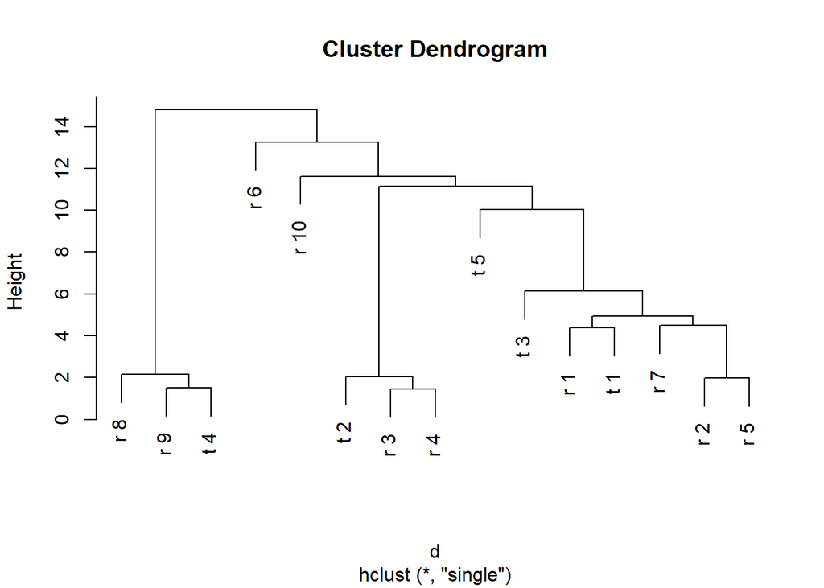

```r
#CAH par le lien simple
h<-hclust(d, method = "single", members = NULL)
plot(h)
```

```r
listClass<-function(cah){
  mg<-cah$merge
  lab<-cah$labels
  res<-list()

  comp1<-NULL
  comp2<-NULL

  for(i in 1:14){

    if(mg[i,1]<0) comp1 = lab[-mg[i,1]]
    else comp1 = res[[mg[i,1]]]

    if(mg[i,2]<0) comp2 = lab[-mg[i,2]]
    else comp2 = res[[mg[i,2]]]

    res[[i]] = c(comp1,comp2)
  }

  return(res)
}
```

```r
Lclass<-listClass(h)

Lclass
```

```
## [[1]]
## [1] "r 3" "r 4"
##
## [[2]]
## [1] "r 9" "t 4"
##
## [[3]]
## [1] "r 2" "r 5"
##
## [[4]]
## [1] "t 2" "r 3" "r 4"
##
## [[5]]
## [1] "r 8" "r 9" "t 4"
##
## [[6]]
## [1] "r 1" "t 1"
##
## [[7]]
## [1] "r 7" "r 2" "r 5"
##
## [[8]]
## [1] "r 1" "t 1" "r 7" "r 2" "r 5"
##
## [[9]]
## [1] "t 3" "r 1" "t 1" "r 7" "r 2" "r 5"
##
## [[10]]
## [1] "t 5" "t 3" "r 1" "t 1" "r 7" "r 2" "r 5"
##
## [[11]]
##  [1] "t 2" "r 3" "r 4" "t 5" "t 3" "r 1" "t 1" "r 7" "r 2" "r 5"
##
## [[12]]
##  [1] "r 10" "t 2"  "r 3"  "r 4"  "t 5"  "t 3"  "r 1"  "t 1"  "r 7"  "r 2"
## [11] "r 5"
##
## [[13]]
##  [1] "r 6"  "r 10" "t 2"  "r 3"  "r 4"  "t 5"  "t 3"  "r 1"  "t 1"  "r 7"
## [11] "r 2"  "r 5"
##
## [[14]]
##  [1] "r 8"  "r 9"  "t 4"  "r 6"  "r 10" "t 2"  "r 3"  "r 4"  "t 5"  "t 3"
## [11] "r 1"  "t 1"  "r 7"  "r 2"  "r 5"
```

## Question 4. (Sébastien Vingadessin)

### Fonction qui, pour chaque visage test, déternine la plus petite classe non triviale contenant le visage test considéré

```r
pluspetiteClasse<-function(listC){
  res<-list("0","0","0","0","0")
  lab<-h$labels
  class<-NULL
  for(t in 1:5){

    for(i in 1:14){
      class=listC[[i]]

      for(j in 1:length(class)){
        if(class[j] == lab[t+10]){
          res[[t]] = class
          break
        }
      }
      if(length(res[[t]]) > 1) break
    }

  }
  return(res)
}

testClass<-pluspetiteClasse(Lclass)
testClass
```

```
## [[1]]
## [1] "r 1" "t 1"
##
## [[2]]
## [1] "t 2" "r 3" "r 4"
##
## [[3]]
## [1] "t 3" "r 1" "t 1" "r 7" "r 2" "r 5"
##
## [[4]]
## [1] "r 9" "t 4"
##
## [[5]]
## [1] "t 5" "t 3" "r 1" "t 1" "r 7" "r 2" "r 5"
```

## Question 5 (Ben yamine Mze Hamadi et Sébastien Vingadessin)

### Fonction qui, pour chaque visage test, affiche simultanément les visages de la plus petite classe déterminée à la question précédente

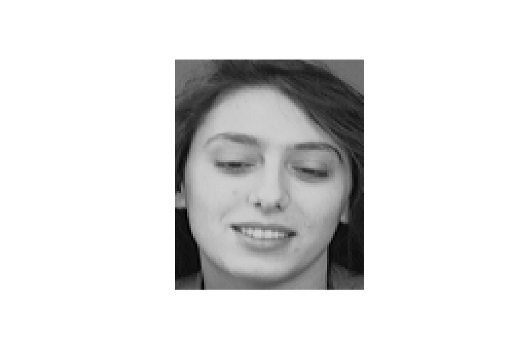

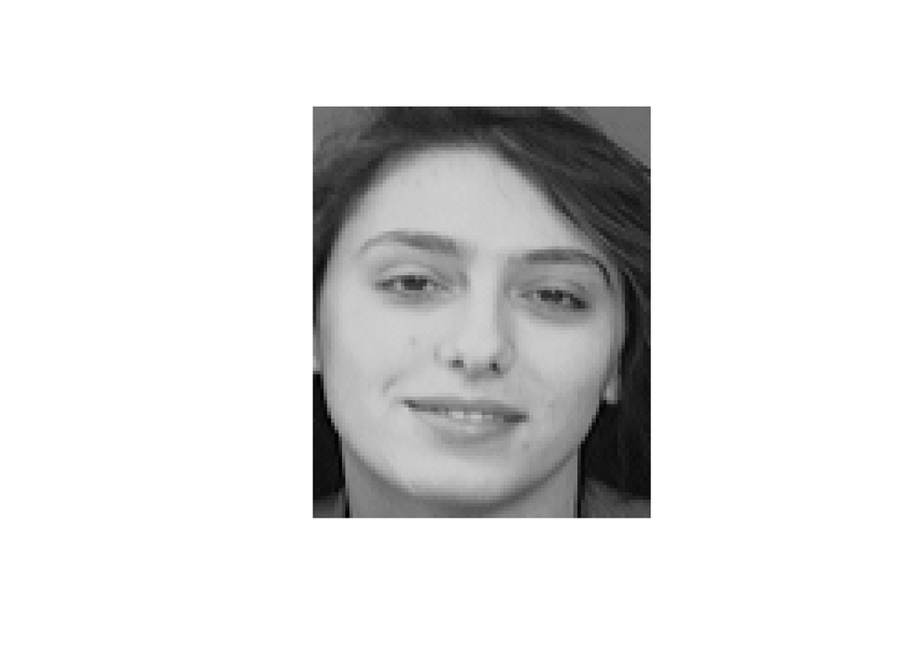

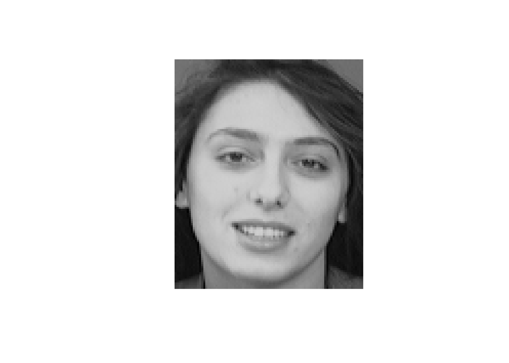

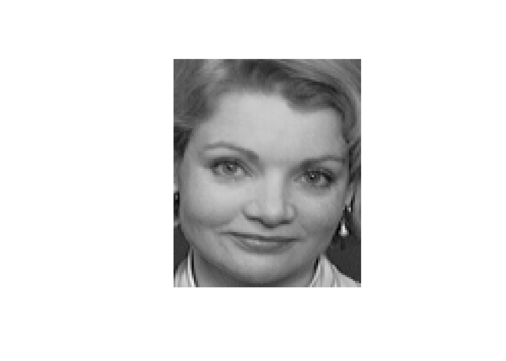

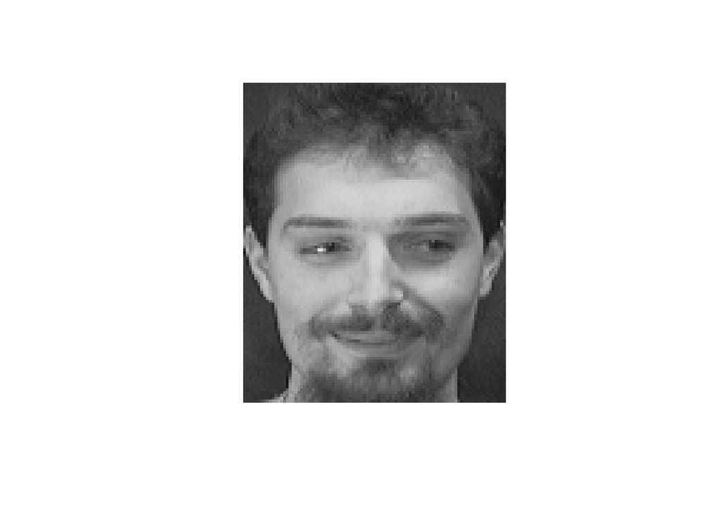

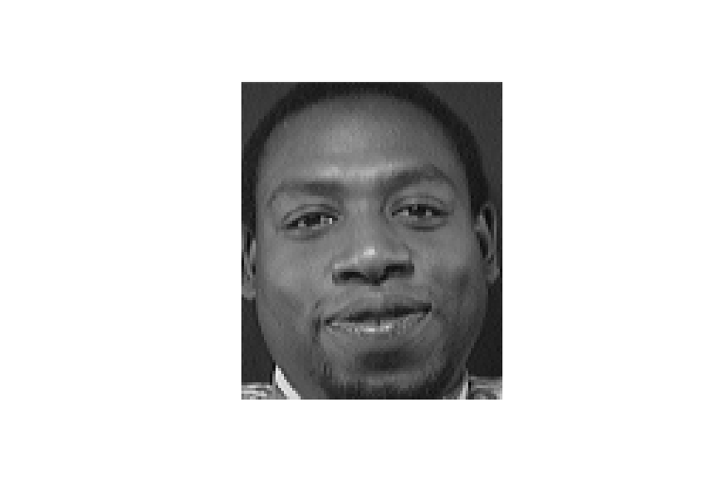

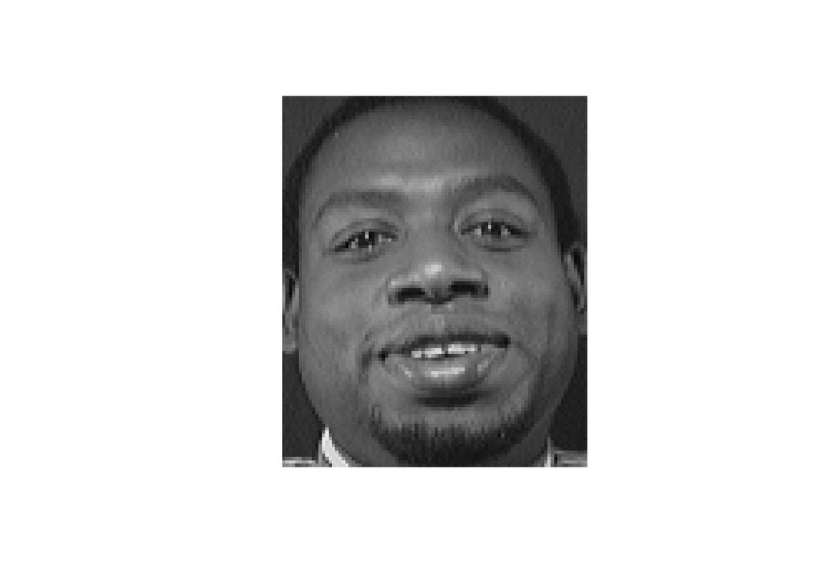

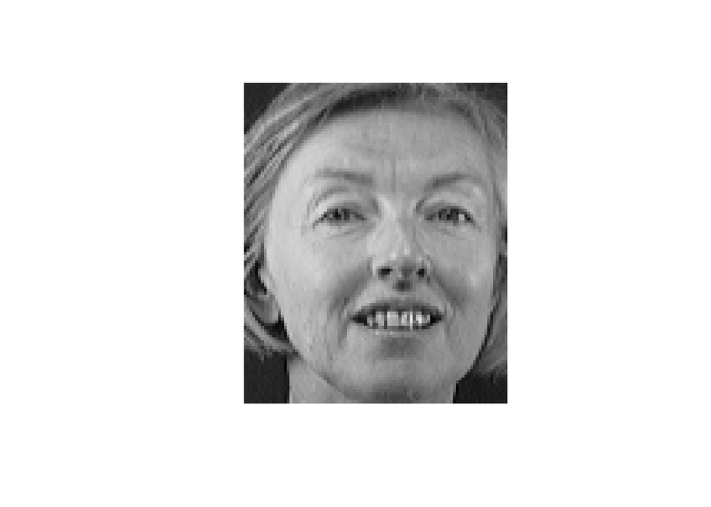

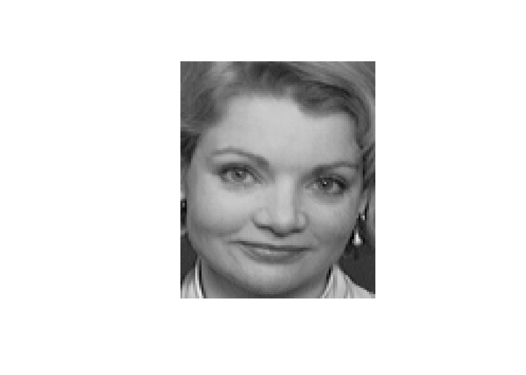

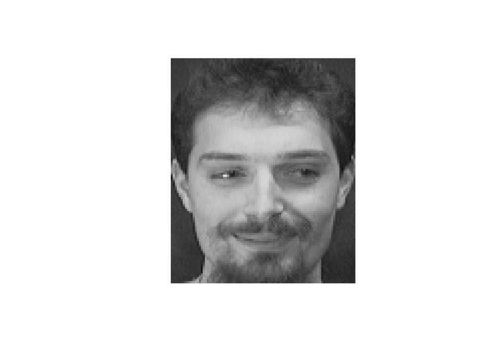

```r
visageClasse<-function(tClass){
  allImg<-c(imgRef,imgTest)
  class<-NULL

  for(i in 1:5){
    class=tClass[[i]]

    for(j in 1:length(class)){
      im<-class[j]
      for(p in 1:15){
        if(im == h$labels[p]){
          lapply(allImg[p],plot)
          break
        }
      }
    }

  }
}

visageClasse(testClass)
```